# Analyse Spatiale Dans R

### 0.2.3 Réaliser une Carte avec la fonction **geom_sf**

`geom_sf()` est une géométrie dans le package `ggplot2` qui permet de visualiser des données spatiales dans **R**. Il est spécialement conçu pour travailler avec des données géospatiales structurées dans le format sf (simple features) et est conçu pour remplacer la géométrie `geom_map()` utilisée dans les versions antérieures de `ggplot2`.

Pour utiliser `geom_sf()`, vous devez d’abord avoir des données géospatiales sous forme de sf object, puis les charger dans ggplot2 en utilisant la fonction `ggplot()`.Example d’utilisation:

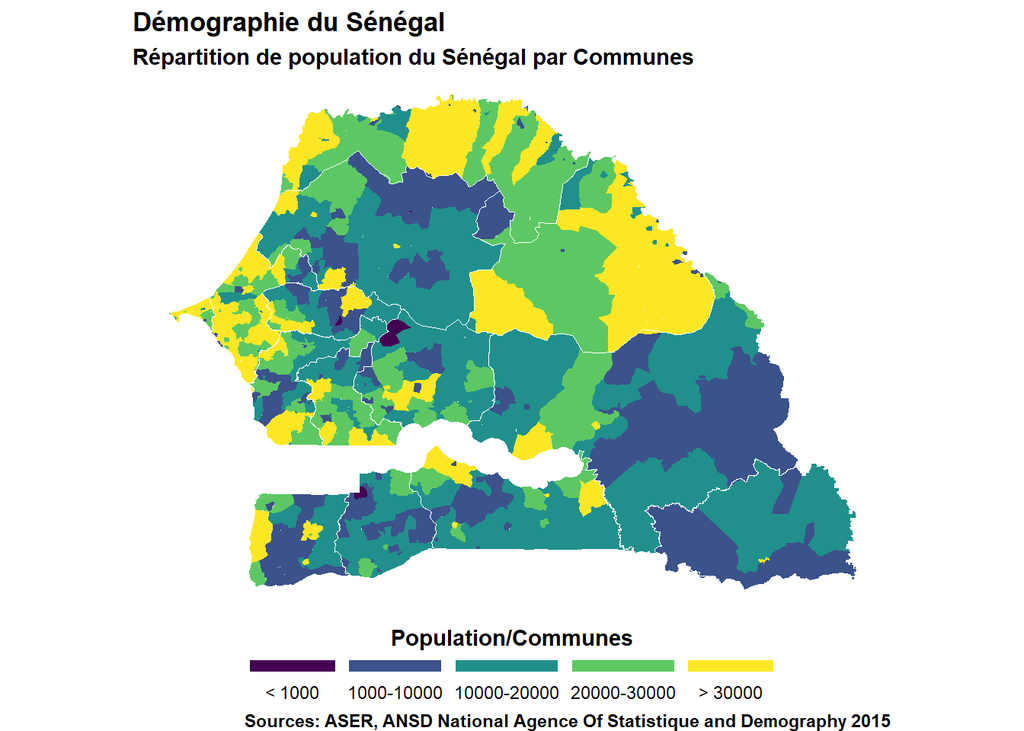

```r
ggplot()+
  geom_sf(aes(fill = Density),color = 'transparent', data = communes)+
  geom_sf(fill = 'transparent', color = 'white', data = regions) +
  scale_fill_viridis_d(name = "Population/Communes",
                       guide = guide_legend(
                         direction = 'horizontal',
                         title.position = 'top',
                         title.hjust = .5,
                         label.hjust = .5,
                         label.position = 'bottom',
                         keywidth = 3,
                         keyheight = .5
                       ))+
  labs(title = "Démographie du Sénégal",
       subtitle = "Répartition de population du Sénégal par Communes",
       caption = c("Sources: ASER, ANSD National Agence Of Statistique and Demography 2015"))+
  theme_void()+
  theme(title = element_text(face = 'bold'),
        legend.position = 'bottom')
```

### 0.2.4 Analyse Exploratoire **EDA**

L’analyse exploratoire des données (EDA en anglais) est une étape importante dans le processus d’analyse des données, qui consiste à examiner les données pour découvrir les relations, les modèles et les tendances cachées. L’objectif principal de l’EDA est de comprendre les données sous différents angles, en utilisant des techniques graphiques et statistiques pour mieux les visualiser et les comprendre. Ici il est possible d’utiliser la fonction `st_drop_geometry` pour avoir un DataFrame avec la table attributaire de notre jeux de données **Shapefile**

```r
library(DT)
data <- st_drop_geometry(communes)
data %>% select(REG, DEPT, CCRCA, SUP_HA, Milieu, Masculin, Feminin, TOTAL) %>%
  head(5) %>%
  datatable()
```

|  | REG | DEPT | CCRCA | SUP_HA | Milieu | Masculin | Feminin | TOTAL |
| --- | --- | --- | --- | --- | --- | --- | --- | --- |
| 1 | DAKAR | DAKAR | CAMBERENE | 176.211179151 | Urbain | 26287 | 26133 | 52420 |
| 2 | DAKAR | DAKAR | PARCELLES ASSAINIES | 361.229493686 | Urbain | 80792 | 78706 | 159498 |
| 3 | DAKAR | DAKAR | PATTE D'OIE | 319.680255445 | Urbain | 20126 | 20980 | 41106 |
| 4 | DAKAR | DAKAR | YOFF | 1385.58954765 | Urbain | 42639 | 46803 | 89442 |
| 5 | DAKAR | DAKAR | NGOR | 435.023028118 | Urbain | 8734 | 8649 | 17383 |

L’agrégation de données est le processus de regroupement de données selon certaines caractéristiques ou dimensions et la création de sommaires ou d’informations agrégées à partir de ces données. Ce processus est souvent utilisé pour résumer de grandes quantités de données en informations plus facilement compréhensibles et exploitables.Dans cet example il est possible d’utiliser les fonctions `group_by` et `summarise` dans la package `dplyr` pour faire une aggrégation des donées faire l’intégration avec la bibliothéque `DT` afin d’avoir une idée plus précise de notre **DataFrame**.

```r
library(DT)
data %>%
  group_by(REG) %>%
  summarise(Population = sum(TOTAL)) %>%
  datatable()
```

|  | REG | Population |
| --- | --- | --- |
| 1 | DAKAR | 3137196 |
| 2 | DIOURBEL | 1497460 |
| 3 | FATICK | 706240 |
| 4 | KAFFRINE | 566987 |
| 5 | KAOLACK | 960877 |
| 6 | KEDOUGOU | 151357 |
| 7 | KOLDA | 642716 |
| 8 | LOUGA | 874197 |
| 9 | MATAM | 576620 |
| 10 | SAINT-LOUIS | 908945 |

[output cut: 4 more lines]

### 0.2.5 Graphique en Colonne Verticale avec `ggplot2`

[figure not shown]

```r
options(scipen = 999)
library(scales)
data %>%
  group_by(REG) %>%
  summarise(Population = sum(TOTAL)) %>%
  ggplot(aes(x = reorder(REG,-Population),y =  Population)) +
  geom_col(color = 'tomato', fill = 'tomato') +
  theme_minimal() +
  labs(title = "Population par Régions",
       subtitle = "Répartition de la population du Sénégal par région en 2015",
       x = "Population",
       y = "Régions") +
  theme(axis.text.x = element_text(angle = 90, vjust = 0.5, hjust=1))
```

### 0.2.6 La fonction `pivot_longer`

pivot_longer() est une fonction de transformation de données dans le package tidyr de R qui permet de transformer un jeu de données d’un format large en un format long en fusionnant plusieurs colonnes en une seule colonne avec des noms de colonne séparés par un caractère commun.

```r
data_long <- data %>%
  group_by(REG) %>%
  summarise(Masculin = sum(Masculin), Feminin = sum(Feminin)) %>%
  pivot_longer(!REG, names_to = "Groupe", values_to = "Valeur") %>%
  ungroup() %>%
  arrange(Valeur) %>%
  mutate(order = row_number())
```

### 0.2.7 Graphique en Colonne Verticale Groupé avec `ggplot2`

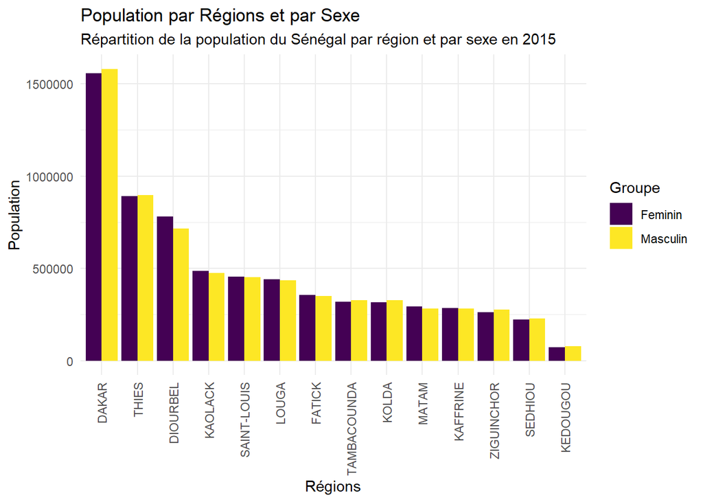

```r
ggplot(data_long, aes(x = reorder(REG, -Valeur), fill=Groupe, y=Valeur)) +
  geom_bar(position="dodge", stat="identity", ) +
  scale_fill_viridis_d() +
  theme_minimal() +
  labs(title = "Population par Régions et par Sexe",
       subtitle = "Répartition de la population du Sénégal par région et par sexe en 2015",
       x = "Régions",
       y = "Population") +
  theme(axis.text.x = element_text(angle = 90, vjust = 0.5, hjust=1))
```

### 0.2.8 Conclusion

R et RStudio sont des outils puissants pour l’analyse de données spatiales, et il existe de nombreux packages disponibles pour vous aider à exploiter pleinement les capacités de ces outils. Il est donc important de prendre le temps d’apprendre à utiliser ces packages et de comprendre les concepts sous-jacents pour pouvoir réaliser des analyses spatiales efficaces.